# Wrangle and Analyse Datas

## Introduction:

> This project involves wrangling data from various sources associated with tweets from the twitter account @dog_rates. WeRateDogs rate's pictures of users' dogs in a humorous manner. Most often they give rating more than 10/10.  
> After scraping the data from various sources listed in the Udacity's Project Details, the data was cleaned after identifying the quality and tidiness issues.  
> Three visualisations were created to analyse the data.

# Visualisations:

## 1. Avg Rating Vs Dog Stage

- Ratings were standardised and then average was taken based on each dog stage and then the plot was made for analysis.

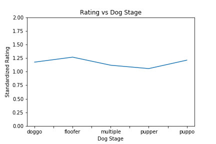

### Observations:

- It can be observed that floofer dog stage was given high ratings when compared to others.
- Pupper has the least average rating when compared to others.

## 2. Rating over Time

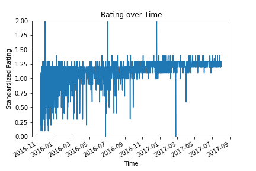

- Some of the dogs are given rating higher than 10.
- I assumed that almost all dogs were given a rating higher than 10. But, some of the ratings were below 10 too.
- So, I standardized the ratings by dividing numerator by denominator.
- I fixed my relative rating range from 0-2 since there were outliers like 42 and 177.6

### Observations:

- Overtime the frequency of ratings below 1 decreases.
- Before 2016-11 there are many ratings below 1. After that they are lessin count.

## 3. Favorite vs Retweet Count

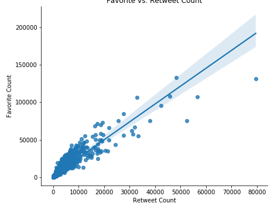

- WeRateDogs have over 4 million followers. Thereforre their tweets are likely to gey many favorites and retweets.